# RCTs with baseline and follow-up measurements of a continuous outcome

Marco Cattaneo

Department of Clinical Research, University of Basel

18 November 2025

## pre-post design

statistical analysis of `trt` effect in RCT with `bsl` and `fup` measurements of a continuous outcome (`y`):

- `fup ~ trt`: **outcome** without considering baseline
- `fup - bsl ~ trt`: **change** from baseline
- `fup ~ trt + bsl`: **ANCOVA** (with or without interaction)
- `y ~ trt * time + pat`: **longitudinal** with random/fixed effects for `pat` (with or without `trt` effect at baseline)

all methods can be extended in various ways (covariate adjustment, heteroskedasticity, additional correlations due to centers/patients, …)

## methods comparison

- all methods estimate the *same* quantity in RCTs (under the corresponding model assumptions)
- if we have an *unbalanced* baseline in an RCT, then completely ignoring the baseline can be problematic, and considering only the change from baseline can be problematic as well (ceiling/floor effect)
- in observational studies, it is in general not clear what exactly we want to estimate and whether we should adjust for the baseline value (see e.g. *Lord’s paradox*)
- there is a large, partially *conflicting* literature comparing the methods in RCTs and observational studies (authors often simulate from one model and find out that the corresponding method is best…)
- I simulated some non-normal bivariate data that may resemble data often met in RCTs: all methods are based on *incorrect* distributional assumptions!

## simulations

```r
load("res.rda")
library(MASS)
library(ggplot2)
library(lme4)
library(lmerTest)
library(pbkrtest)
library(future.apply)
set.seed(0)

n = 1000000
mu0 = c(0,2)
mu1 = c(0,3)
Sigma = matrix(c(2,1,1,2),2)
dat = rbind(mvrnorm(n/2, mu0, Sigma), mvrnorm(n/2, mu1, Sigma)) |>
  (\(x) tanh(x/5)*5+5)()
round(colMeans(dat[1:(n/2),]),2)  # means bsl/fup for trt0
```

```
[1] 5.00 6.78
```

```r
round(cov(dat[1:(n/2),]), 2)  # cov matrix bsl/fup for trt0
```

```
     [,1] [,2]
[1,] 1.74 0.76
[2,] 0.76 1.36
```

```r
round(colMeans(dat[n/2+1:(n/2),]),2)  # means bsl/fup for trt1
```

```
[1] 5.00 7.54
```

```r
round(cov(dat[n/2+1:(n/2),]),2)  # cov matrix bsl/fup for trt1
```

```
     [,1] [,2]
[1,] 1.74 0.65
[2,] 0.65 1.01
```

```r
es = mean(dat[n/2+1:(n/2),2])-mean(dat[1:(n/2),2])
round(es, 2)  # effect size of trt (difference in mean fup)
```

```
[1] 0.76
```

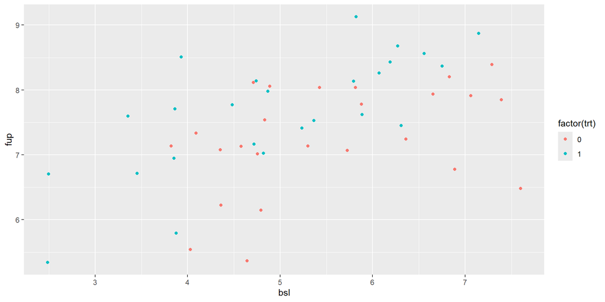

```r
n = 50
dat = rbind(mvrnorm(n/2, mu0, Sigma), mvrnorm(n/2, mu1, Sigma)) |>
  (\(x) tanh(x/5)*5+5)()
db.wide = data.frame(pat = 1:n, bsl = dat[,1], fup = dat[,2], trt = rep(0:1, each = n/2))
db.long = reshape(db.wide, c("bsl","fup"), "y", "time", times = 0:1, direction = "long")
db.long$trt.b = factor(db.long$trt + 2*(1-db.long$time), 0:3, c(0:1,"b","b"))
ggplot(db.wide, aes(bsl, fup, color = factor(trt))) +
  geom_point()
```

```r
# outcome without considering baseline
summary(lm(fup ~ trt, db.wide))
```

```
Call:
lm(formula = fup ~ trt, data = db.wide)

Residuals:
     Min       1Q   Median       3Q      Max
-2.33255 -0.42923  0.00668  0.68734  1.45364

Coefficients:
            Estimate Std. Error t value Pr(>|t|)
(Intercept)   7.2616     0.1740  41.729   <2e-16 ***
trt           0.4122     0.2461   1.675      0.1
---
Signif. codes:  0 '***' 0.001 '**' 0.01 '*' 0.05 '.' 0.1 ' ' 1

Residual standard error: 0.8701 on 48 degrees of freedom
Multiple R-squared:  0.05521,   Adjusted R-squared:  0.03553
F-statistic: 2.805 on 1 and 48 DF,  p-value: 0.1005
```

```r
# change from baseline
summary(lm((fup - bsl) ~ trt, db.wide))
```

```
Call:
lm(formula = (fup - bsl) ~ trt, data = db.wide)

Residuals:
    Min      1Q  Median      3Q     Max
-2.8555 -0.6115 -0.2386  0.6748  1.8775

Coefficients:
            Estimate Std. Error t value Pr(>|t|)
(Intercept)   1.7384     0.2038   8.531 3.51e-11 ***
trt           0.9616     0.2882   3.337  0.00164 **
---
Signif. codes:  0 '***' 0.001 '**' 0.01 '*' 0.05 '.' 0.1 ' ' 1

Residual standard error: 1.019 on 48 degrees of freedom
Multiple R-squared:  0.1883,    Adjusted R-squared:  0.1714
F-statistic: 11.13 on 1 and 48 DF,  p-value: 0.001642
```

```r
# ANCOVA with one slope
summary(lm(fup ~ trt + bsl, db.wide))
```

```
Call:
lm(formula = fup ~ trt + bsl, data = db.wide)

Residuals:
    Min      1Q  Median      3Q     Max
-1.6291 -0.3667  0.1306  0.4569  1.2626

Coefficients:
            Estimate Std. Error t value Pr(>|t|)
(Intercept)  4.99799    0.47595  10.501 6.46e-14 ***
trt          0.63735    0.20618   3.091  0.00335 **
bsl          0.40984    0.08223   4.984 8.88e-06 ***
---
Signif. codes:  0 '***' 0.001 '**' 0.01 '*' 0.05 '.' 0.1 ' ' 1

Residual standard error: 0.7112 on 47 degrees of freedom
Multiple R-squared:  0.3819,    Adjusted R-squared:  0.3556
F-statistic: 14.52 on 2 and 47 DF,  p-value: 1.231e-05
```

```r
# ANCOVA with two slopes
summary(lm(fup ~ trt * scale(bsl), db.wide))
```

```
Call:
lm(formula = fup ~ trt * scale(bsl), data = db.wide)

Residuals:
     Min       1Q   Median       3Q      Max
-1.64173 -0.37086  0.08824  0.46115  1.36494

Coefficients:
               Estimate Std. Error t value Pr(>|t|)
(Intercept)      7.1825     0.1450  49.542  < 2e-16 ***
trt              0.6309     0.2045   3.085  0.00344 **
scale(bsl)       0.3646     0.1546   2.359  0.02263 *
trt:scale(bsl)   0.2788     0.2077   1.342  0.18614
---
Signif. codes:  0 '***' 0.001 '**' 0.01 '*' 0.05 '.' 0.1 ' ' 1

Residual standard error: 0.7052 on 46 degrees of freedom
Multiple R-squared:  0.4052,    Adjusted R-squared:  0.3664
F-statistic: 10.44 on 3 and 46 DF,  p-value: 2.333e-05
```

```r
# fixed-eff longitudinal with one baseline (corresponds to change from baseline)
summary(lm(y ~ trt.b + factor(pat), db.long))
```

```
Call:
lm(formula = y ~ trt.b + factor(pat), data = db.long)

Residuals:
    Min      1Q  Median      3Q     Max
-1.4277 -0.3257  0.0000  0.3257  1.4277

Coefficients:
              Estimate Std. Error t value Pr(>|t|)
(Intercept)    8.35573    0.51952  16.084  < 2e-16 ***
trt.b1         0.96161    0.28818   3.337 0.001642 **
trt.bb        -1.73838    0.20377  -8.531 3.51e-11 ***
factor(pat)2   0.03067    0.72045   0.043 0.966225
factor(pat)3  -1.60129    0.72045  -2.223 0.030985 *
factor(pat)4  -0.75546    0.72045  -1.049 0.299616
factor(pat)5  -0.68529    0.72045  -0.951 0.346268
factor(pat)6  -1.26744    0.72045  -1.759 0.084909 .
factor(pat)7  -1.77220    0.72045  -2.460 0.017552 *
factor(pat)8  -1.77219    0.72045  -2.460 0.017552 *
factor(pat)9  -2.48139    0.72045  -3.444 0.001198 **
factor(pat)10 -1.30084    0.72045  -1.806 0.077255 .
factor(pat)11 -0.65782    0.72045  -0.913 0.365770
factor(pat)12 -0.19312    0.72045  -0.268 0.789808
factor(pat)13 -2.19266    0.72045  -3.043 0.003787 **
factor(pat)14 -0.65437    0.72045  -0.908 0.368269
factor(pat)15 -0.44374    0.72045  -0.616 0.540857
factor(pat)16  0.13527    0.72045   0.188 0.851859
factor(pat)17 -2.00798    0.72045  -2.787 0.007596 **
factor(pat)18 -2.01766    0.72045  -2.801 0.007330 **
factor(pat)19 -2.69980    0.72045  -3.747 0.000480 ***
factor(pat)20  0.35317    0.72045   0.490 0.626219
factor(pat)21 -1.63116    0.72045  -2.264 0.028124 *
factor(pat)22 -1.07479    0.72045  -1.492 0.142283
factor(pat)23 -1.08937    0.72045  -1.512 0.137070
factor(pat)24 -0.56002    0.72045  -0.777 0.440784
factor(pat)25 -1.01276    0.72045  -1.406 0.166240
factor(pat)26 -0.40800    0.73471  -0.555 0.581258
factor(pat)27 -1.84039    0.73471  -2.505 0.015697 *
factor(pat)28 -0.80240    0.73471  -1.092 0.280228
factor(pat)29 -4.05415    0.73471  -5.518 1.35e-06 ***
```

[output cut: 12 more lines]

```
factor(pat)42 -0.40932    0.73471  -0.557 0.580039
factor(pat)43 -2.49290    0.73471  -3.393 0.001393 **
factor(pat)44 -1.64385    0.73471  -2.237 0.029938 *
factor(pat)45 -1.52581    0.73471  -2.077 0.043202 *
factor(pat)46  0.04269    0.73471   0.058 0.953912
factor(pat)47 -2.02597    0.73471  -2.757 0.008214 **
factor(pat)48 -2.56599    0.73471  -3.493 0.001038 **
factor(pat)49 -0.49123    0.73471  -0.669 0.506950
factor(pat)50 -2.88272    0.73471  -3.924 0.000277 ***
---
Signif. codes:  0 '***' 0.001 '**' 0.01 '*' 0.05 '.' 0.1 ' ' 1

Residual standard error: 0.7204 on 48 degrees of freedom
Multiple R-squared:  0.8963,    Adjusted R-squared:  0.786
F-statistic: 8.131 on 51 and 48 DF,  p-value: 8.409e-12
```

```r
# fixed-eff longitudinal with two baselines (corresponds to change from baseline)
summary(lm(y ~ trt * time + factor(pat), db.long))
```

```
Call:
lm(formula = y ~ trt * time + factor(pat), data = db.long)

Residuals:
    Min      1Q  Median      3Q     Max
-1.4277 -0.3257  0.0000  0.3257  1.4277

Coefficients: (1 not defined because of singularities)
              Estimate Std. Error t value Pr(>|t|)
(Intercept)    6.61735    0.51952  12.737  < 2e-16 ***
trt           -2.88272    0.73471  -3.924 0.000277 ***
time           1.73838    0.20377   8.531 3.51e-11 ***
factor(pat)2   0.03067    0.72045   0.043 0.966225
factor(pat)3  -1.60129    0.72045  -2.223 0.030985 *
factor(pat)4  -0.75546    0.72045  -1.049 0.299616
factor(pat)5  -0.68529    0.72045  -0.951 0.346268
factor(pat)6  -1.26744    0.72045  -1.759 0.084909 .
factor(pat)7  -1.77220    0.72045  -2.460 0.017552 *
factor(pat)8  -1.77219    0.72045  -2.460 0.017552 *
factor(pat)9  -2.48139    0.72045  -3.444 0.001198 **
factor(pat)10 -1.30084    0.72045  -1.806 0.077255 .
factor(pat)11 -0.65782    0.72045  -0.913 0.365770
factor(pat)12 -0.19312    0.72045  -0.268 0.789808
factor(pat)13 -2.19266    0.72045  -3.043 0.003787 **
factor(pat)14 -0.65437    0.72045  -0.908 0.368269
factor(pat)15 -0.44374    0.72045  -0.616 0.540857
factor(pat)16  0.13527    0.72045   0.188 0.851859
factor(pat)17 -2.00798    0.72045  -2.787 0.007596 **
factor(pat)18 -2.01766    0.72045  -2.801 0.007330 **
factor(pat)19 -2.69980    0.72045  -3.747 0.000480 ***
factor(pat)20  0.35317    0.72045   0.490 0.626219
factor(pat)21 -1.63116    0.72045  -2.264 0.028124 *
factor(pat)22 -1.07479    0.72045  -1.492 0.142283
factor(pat)23 -1.08937    0.72045  -1.512 0.137070
factor(pat)24 -0.56002    0.72045  -0.777 0.440784
factor(pat)25 -1.01276    0.72045  -1.406 0.166240
factor(pat)26  2.47472    0.72045   3.435 0.001231 **
factor(pat)27  1.04232    0.72045   1.447 0.154460
factor(pat)28  2.08031    0.72045   2.888 0.005807 **
factor(pat)29 -1.17143    0.72045  -1.626 0.110503
```

[output cut: 13 more lines]

```
factor(pat)43  0.38981    0.72045   0.541 0.590960
factor(pat)44  1.23886    0.72045   1.720 0.091953 .
factor(pat)45  1.35691    0.72045   1.883 0.065709 .
factor(pat)46  2.92540    0.72045   4.061 0.000180 ***
factor(pat)47  0.85675    0.72045   1.189 0.240215
factor(pat)48  0.31672    0.72045   0.440 0.662185
factor(pat)49  2.39148    0.72045   3.319 0.001728 **
factor(pat)50       NA         NA      NA       NA
trt:time       0.96161    0.28818   3.337 0.001642 **
---
Signif. codes:  0 '***' 0.001 '**' 0.01 '*' 0.05 '.' 0.1 ' ' 1

Residual standard error: 0.7204 on 48 degrees of freedom
Multiple R-squared:  0.8963,    Adjusted R-squared:  0.786
F-statistic: 8.131 on 51 and 48 DF,  p-value: 8.409e-12
```

```r
# mixed-eff longitudinal with one baseline
summary(lmer(y ~ trt.b + (1|pat), db.long))
```

```
Linear mixed model fit by REML. t-tests use Satterthwaite's method ['lmerModLmerTest']
Formula: y ~ trt.b + (1 | pat)
   Data: db.long

REML criterion at convergence: 284.6

Scaled residuals:
     Min       1Q   Median       3Q      Max
-1.87718 -0.49717  0.00964  0.52858  2.39153

Random effects:
 Groups   Name        Variance Std.Dev.
 pat      (Intercept) 0.6688   0.8178
 Residual             0.5242   0.7240
Number of obs: 100, groups:  pat, 50

Fixed effects:
            Estimate Std. Error      df t value Pr(>|t|)
(Intercept)   7.1076     0.2006 96.0272  35.439  < 2e-16 ***
trt.b1        0.7202     0.2558 72.7491   2.815  0.00627 **
trt.bb       -1.8591     0.1932 57.4925  -9.622 1.39e-13 ***
---
Signif. codes:  0 '***' 0.001 '**' 0.01 '*' 0.05 '.' 0.1 ' ' 1

Correlation of Fixed Effects:
       (Intr) trt.b1
trt.b1 -0.638
trt.bb -0.693  0.662
```

```r
summary(lmer(y ~ trt.b + (1|pat), db.long), ddf = "Kenward-Roger")
```

```
Linear mixed model fit by REML. t-tests use Kenward-Roger's method ['lmerModLmerTest']
Formula: y ~ trt.b + (1 | pat)
   Data: db.long

REML criterion at convergence: 284.6

Scaled residuals:
     Min       1Q   Median       3Q      Max
-1.87718 -0.49717  0.00964  0.52858  2.39153

Random effects:
 Groups   Name        Variance Std.Dev.
 pat      (Intercept) 0.6688   0.8178
 Residual             0.5242   0.7240
Number of obs: 100, groups:  pat, 50

Fixed effects:
            Estimate Std. Error      df t value Pr(>|t|)
(Intercept)   7.1076     0.2017 96.0569  35.236  < 2e-16 ***
trt.b1        0.7202     0.2594 73.3136   2.776  0.00698 **
trt.bb       -1.8591     0.1944 58.2228  -9.562 1.53e-13 ***
---
Signif. codes:  0 '***' 0.001 '**' 0.01 '*' 0.05 '.' 0.1 ' ' 1

Correlation of Fixed Effects:
       (Intr) trt.b1
trt.b1 -0.638
trt.bb -0.693  0.662
```

```r
# mixed-eff longitudinal with two baselines (corresponds to change from baseline)
summary(lmer(y ~ trt * time + (1|pat), db.long))
```

```
Linear mixed model fit by REML. t-tests use Satterthwaite's method ['lmerModLmerTest']
Formula: y ~ trt * time + (1 | pat)
   Data: db.long

REML criterion at convergence: 282

Scaled residuals:
     Min       1Q   Median       3Q      Max
-1.73662 -0.49960  0.00951  0.58134  2.24256

Random effects:
 Groups   Name        Variance Std.Dev.
 pat      (Intercept) 0.6387   0.7992
 Residual             0.5190   0.7204
Number of obs: 100, groups:  pat, 50

Fixed effects:
            Estimate Std. Error      df t value Pr(>|t|)
(Intercept)   5.5233     0.2152 73.6000  25.666  < 2e-16 ***
trt          -0.5494     0.3043 73.6000  -1.805  0.07510 .
time          1.7384     0.2038 48.0000   8.531 3.51e-11 ***
trt:time      0.9616     0.2882 48.0000   3.337  0.00164 **
---
Signif. codes:  0 '***' 0.001 '**' 0.01 '*' 0.05 '.' 0.1 ' ' 1

Correlation of Fixed Effects:
         (Intr) trt    time
trt      -0.707
time     -0.473  0.335
trt:time  0.335 -0.473 -0.707
```

```r
summary(lmer(y ~ trt * time + (1|pat), db.long), ddf = "Kenward-Roger")
```

```
Linear mixed model fit by REML. t-tests use Kenward-Roger's method ['lmerModLmerTest']
Formula: y ~ trt * time + (1 | pat)
   Data: db.long

REML criterion at convergence: 282

Scaled residuals:
     Min       1Q   Median       3Q      Max
-1.73662 -0.49960  0.00951  0.58134  2.24256

Random effects:
 Groups   Name        Variance Std.Dev.
 pat      (Intercept) 0.6387   0.7992
 Residual             0.5190   0.7204
Number of obs: 100, groups:  pat, 50

Fixed effects:
            Estimate Std. Error      df t value Pr(>|t|)
(Intercept)   5.5233     0.2152 73.6000  25.666  < 2e-16 ***
trt          -0.5494     0.3043 73.6000  -1.805  0.07510 .
time          1.7384     0.2038 48.0000   8.531 3.51e-11 ***
trt:time      0.9616     0.2882 48.0000   3.337  0.00164 **
---
Signif. codes:  0 '***' 0.001 '**' 0.01 '*' 0.05 '.' 0.1 ' ' 1

Correlation of Fixed Effects:
         (Intr) trt    time
trt      -0.707
time     -0.473  0.335
trt:time  0.335 -0.473 -0.707
```

```r
sim = function(n, mu0, mu1, Sigma) {
  dat = rbind(mvrnorm(n/2, mu0, Sigma), mvrnorm(n/2, mu1, Sigma)) |>
    (\(x) tanh(x/5)*5+5)()
  db.wide = data.frame(pat = 1:n, bsl = dat[,1], fup = dat[,2], trt = rep(0:1, each = n/2))
  db.long = reshape(db.wide, c("bsl","fup"), "y", "time", times = 0:1, direction = "long")
  db.long$trt.b = factor(db.long$trt + 2*(1-db.long$time), 0:3, c(0:1,"b","b"))
  c(summary(lm(fup ~ trt, db.wide))$coef["trt",c(1,4)],
    summary(lm((fup - bsl) ~ trt, db.wide))$coef["trt",c(1,4)],
    summary(lm(fup ~ trt + bsl, db.wide))$coef["trt",c(1,4)],
    summary(lm(fup ~ trt * scale(bsl), db.wide))$coef["trt",c(1,4)],
    summary(lmer(y ~ trt.b + (1|pat), db.long))$coef["trt.b1",c(1,5)],
    summary(lmer(y ~ trt.b + (1|pat), db.long), ddf = "Kenward-Roger")$coef["trt.b1",c(1,5)])}

summarize = function(res, es) {
  tab = round(t(sapply(1:(nrow(res)/2), \(x){
    c(mean(res[2*x-1,])-es,sd(res[2*x-1,]),sqrt(mean((res[2*x-1,]-es)^2)),mean(res[2*x,]<0.05))})), 2)
  colnames(tab) = c("bias", "SD estimate", "RMSE", "power")
  rownames(tab) = c("outcome without considering baseline",
                    "change from baseline",
                    "ANCOVA with one slope",
                    "ANCOVA with two slopes",
                    "mixed-eff longitudinal with one baseline and Satterthwaite approx",
                    "mixed-eff longitudinal with one baseline and Kenward-Roger approx")
  print(tab)}

plan(multisession)
# res1.1 = future_replicate(10000, sim(n, mu0, mu1, Sigma), future.seed = 0)
summarize(res1.1, es)  # change bad, outcome not good, ANCOVA best
```

```
                                                                  bias SD estimate RMSE power
outcome without considering baseline                                 0        0.31 0.31  0.68
change from baseline                                                 0        0.34 0.34  0.56
ANCOVA with one slope                                                0        0.27 0.27  0.78
ANCOVA with two slopes                                               0        0.27 0.27  0.78
mixed-eff longitudinal with one baseline and Satterthwaite approx    0        0.27 0.27  0.73
mixed-eff longitudinal with one baseline and Kenward-Roger approx    0        0.27 0.27  0.71
```

```r
# res0.1 = future_replicate(10000, sim(n, mu0, mu0, Sigma), future.seed = 0)
summarize(res0.1, 0)
```

```
                                                                  bias SD estimate RMSE power
outcome without considering baseline                                 0        0.33 0.33  0.05
change from baseline                                                 0        0.35 0.35  0.05
ANCOVA with one slope                                                0        0.29 0.29  0.05
ANCOVA with two slopes                                               0        0.29 0.29  0.05
mixed-eff longitudinal with one baseline and Satterthwaite approx    0        0.29 0.29  0.04
mixed-eff longitudinal with one baseline and Kenward-Roger approx    0        0.29 0.29  0.04
```

```r
n = 1000000
mu0 = c(2,2)
mu1 = c(2,3)
Sigma = matrix(c(3,2,2,3),2)
dat = rbind(mvrnorm(n/2, mu0, Sigma), mvrnorm(n/2, mu1, Sigma)) |>
  (\(x) tanh(x/5)*5+5)()
round(colMeans(dat[1:(n/2),]),2)  # means bsl/fup for trt0
```

```
[1] 6.73 6.73
```

```r
round(cov(dat[1:(n/2),]), 2)  # cov matrix bsl/fup for trt0
```

```
     [,1] [,2]
[1,] 1.96 1.29
[2,] 1.29 1.96
```

```r
round(colMeans(dat[n/2+1:(n/2),]),2)  # means bsl/fup for trt1
```

```
[1] 6.73 7.48
```

```r
round(cov(dat[n/2+1:(n/2),]),2)  # cov matrix bsl/fup for trt1
```

```
     [,1] [,2]
[1,] 1.97 1.14
[2,] 1.14 1.51
```

```r
es = mean(dat[n/2+1:(n/2),2])-mean(dat[1:(n/2),2])
round(es, 2)  # effect size of trt (difference in mean fup)
```

```
[1] 0.75
```

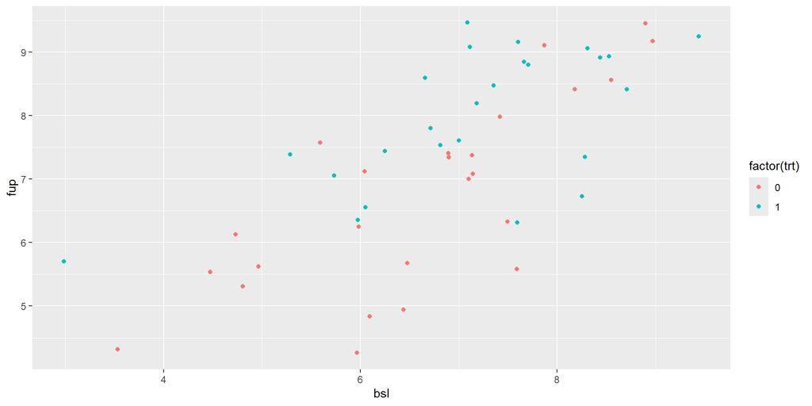

```r
n = 50
dat = rbind(mvrnorm(n/2, mu0, Sigma), mvrnorm(n/2, mu1, Sigma)) |>
  (\(x) tanh(x/5)*5+5)()
db.wide = data.frame(pat = 1:n, bsl = dat[,1], fup = dat[,2], trt = rep(0:1, each = n/2))
ggplot(db.wide, aes(bsl, fup, color = factor(trt))) +
  geom_point()
```

```r
# res1.2 = future_replicate(10000, sim(n, mu0, mu1, Sigma), future.seed = 0)
summarize(res1.2, es)  # outcome bad, change not good
```

```
                                                                  bias SD estimate RMSE power
outcome without considering baseline                                 0        0.38 0.38  0.51
change from baseline                                                 0        0.31 0.31  0.63
ANCOVA with one slope                                                0        0.28 0.28  0.73
ANCOVA with two slopes                                               0        0.28 0.28  0.73
mixed-eff longitudinal with one baseline and Satterthwaite approx    0        0.28 0.28  0.72
mixed-eff longitudinal with one baseline and Kenward-Roger approx    0        0.28 0.28  0.72
```

```r
# res0.2 = future_replicate(10000, sim(n, mu0, mu0, Sigma), future.seed = 0)
summarize(res0.2, 0)
```

```
                                                                  bias SD estimate RMSE power
outcome without considering baseline                                 0        0.40 0.40  0.05
change from baseline                                                 0        0.32 0.32  0.05
ANCOVA with one slope                                                0        0.30 0.30  0.05
ANCOVA with two slopes                                               0        0.30 0.30  0.05
mixed-eff longitudinal with one baseline and Satterthwaite approx    0        0.30 0.30  0.05
mixed-eff longitudinal with one baseline and Kenward-Roger approx    0        0.30 0.30  0.05
```

```r
n = 1000000
mu0 = c(5,7)
mu1 = c(5,8)
Sigma = matrix(c(3,1,1,3),2)
dat = rbind(mvrnorm(n/2, mu0, Sigma), mvrnorm(n/2, mu1, Sigma)) |>
  (\(x) tanh(x/5)*5+5)()
round(colMeans(dat[1:(n/2),]),2)  # means bsl/fup for trt0
```

```
[1] 8.62 9.31
```

```r
round(cov(dat[1:(n/2),]), 2)  # cov matrix bsl/fup for trt0
```

```
     [,1] [,2]
[1,] 0.66 0.12
[2,] 0.12 0.22
```

```r
round(colMeans(dat[n/2+1:(n/2),]),2)  # means bsl/fup for trt1
```

```
[1] 8.62 9.52
```

```r
round(cov(dat[n/2+1:(n/2),]),2)  # cov matrix bsl/fup for trt1
```

```
     [,1] [,2]
[1,] 0.67 0.08
[2,] 0.08 0.11
```

```r
es = mean(dat[n/2+1:(n/2),2])-mean(dat[1:(n/2),2])
round(es, 2)  # effect size of trt (difference in mean fup)
```

```
[1] 0.21
```

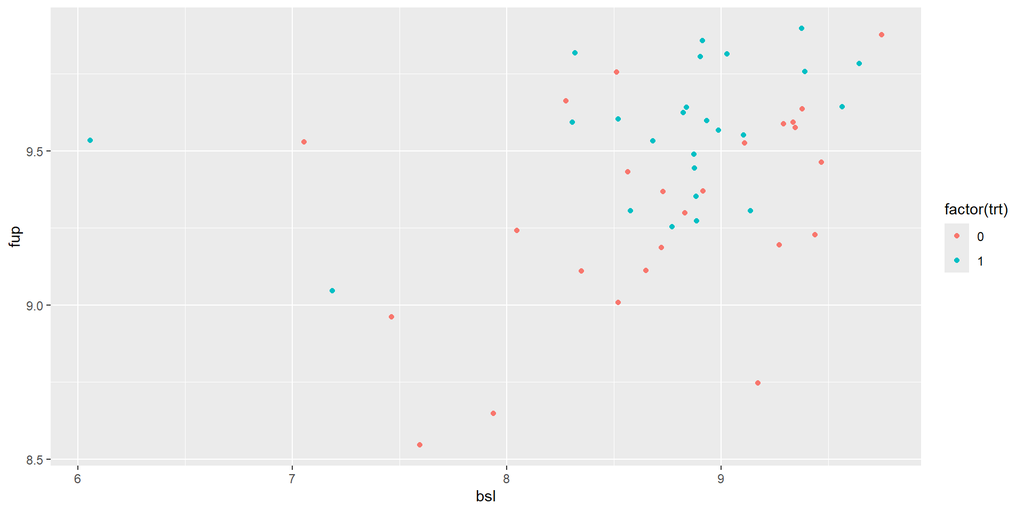

```r
n = 50
dat = rbind(mvrnorm(n/2, mu0, Sigma), mvrnorm(n/2, mu1, Sigma)) |>
  (\(x) tanh(x/5)*5+5)()
db.wide = data.frame(pat = 1:n, bsl = dat[,1], fup = dat[,2], trt = rep(0:1, each = n/2))
ggplot(db.wide, aes(bsl, fup, color = factor(trt))) +
  geom_point()
```

```r
# res1.3 = future_replicate(10000, sim(n, mu0, mu1, Sigma), future.seed = 0)
summarize(res1.3, es)  # change and longitudinal bad (2% singular), ANCOVA best
```

```
                                                                  bias SD estimate RMSE power
outcome without considering baseline                                 0        0.12 0.12  0.46
change from baseline                                                 0        0.22 0.22  0.15
ANCOVA with one slope                                                0        0.11 0.11  0.49
ANCOVA with two slopes                                               0        0.11 0.11  0.50
mixed-eff longitudinal with one baseline and Satterthwaite approx    0        0.11 0.11  0.12
mixed-eff longitudinal with one baseline and Kenward-Roger approx    0        0.11 0.11  0.11
```

```r
# res0.3 = future_replicate(10000, sim(n, mu0, mu0, Sigma), future.seed = 0)
summarize(res0.3, 0)  # longitudinal conservative (2% singular)
```

```
                                                                  bias SD estimate RMSE power
outcome without considering baseline                                 0        0.13 0.13  0.05
change from baseline                                                 0        0.22 0.22  0.05
ANCOVA with one slope                                                0        0.13 0.13  0.05
ANCOVA with two slopes                                               0        0.13 0.13  0.05
mixed-eff longitudinal with one baseline and Satterthwaite approx    0        0.13 0.13  0.01
mixed-eff longitudinal with one baseline and Kenward-Roger approx    0        0.13 0.13  0.01
```

```r
# save(res1.1, res0.1, res1.2, res0.2, res1.3, res0.3, file = "res.rda")
```

## conclusions

- `fup ~ trt` (**outcome** without considering baseline):
  - loss of statistical power when high correlation between baseline and follow-up ❌
  - issues with unbalanced baseline ❌
  - compatibility with nonparametric analysis ✔️
- `fup - bsl ~ trt` (**change** from baseline):
  - loss of statistical power when low correlation between baseline and follow-up ❌
  - issues with unbalanced baseline (ceiling/floor effect) ❌
  - typically more interesting effect size ✔️
  - compatibility with nonparametric analysis ✔️
- `fup ~ trt +/* scale(bsl)` (**ANCOVA** with or without interaction):
  - simple model, quite robust to deviations from assumptions ✔️
  - typically more interesting effect size as adjusted analysis of change ✔️
- `y ~ trt.b + (1|pat)` (mixed-effect **longitudinal** with one baseline):
  - more complex model, not so robust to deviations from assumptions ❌
  - partial observations possible (but limited practical utility) ✔️